# Problem Set 3

Jacob Farmer

Due September 30, 2026

## Potential Outcomes Framework

We will start by using some fake data. This is helpful because this allows us to ‘observe’ the treated and untreated outcome for each individual. They key idea is that if we *know* what the true treatment effect is, we can assess how good of a job our estimators do of finding it under different conditions.

First, let’s generate data on our untreated outcome, y0. Absent treatment, our outcome has a normal distribution with a mean of 50 and a standard deviation of 25. Generate 100,000 observations. We know what this should look like when we plot it

Write some code to create y0 and plot it’s density.

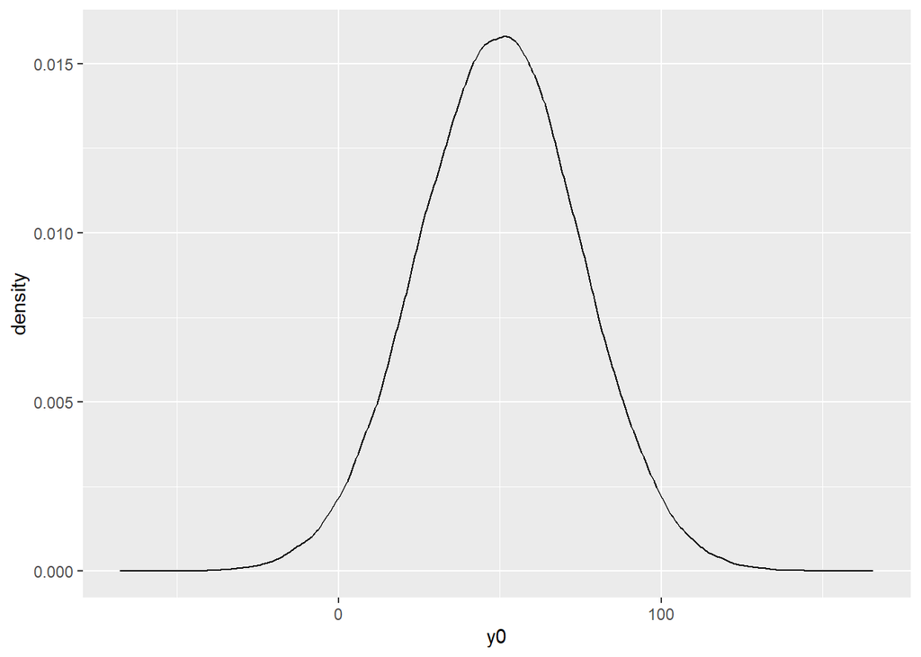

```r
y0 <- data.frame(y0 = rnorm(n = 100000, mean = 50, sd = 25))

ggplot(y0, aes(x = y0)) +
  geom_density()
```

We will assume that everyone has a *potential* treatment effect. That means that everyone would respond to treatment in some way. We will assume the treatment is normally distributed with a mean of 5 and standard deviation of 4.

Create this variable and call it treatment_effect

```r
treatment_effect <- rnorm(n = 100000, mean = 5, sd = 4)
y0$treatment_effect <- treatment_effect
```

How many people have a negative treatment effect? Write some code that answers this question.

```r
num_neg <- sum(y0$treatment_effect < 0)
num_neg
```

```
## [1] 10597
```

In this simulated environment, we can tell exactly what everyone’s outcome would be both with and without treatment. We have already simulated y0, or the outcome without treatment. y1, the outcome with treatment, is simply y0 plus the treatment_effect.

Calculate this variable and store it as y1

```r
y1 = y0$y0 + treatment_effect
```

Write some code that creates a density plot of both treated and untreated outcomes (there is an example of this in the slides). I have started you off by combining y0 and y1 in a data frame. There should be a separate density for each group.

Hint: use the “fill” option within aes().

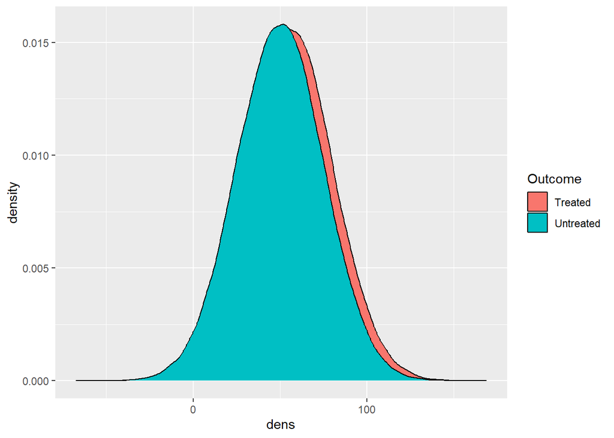

```r
dat <- data.frame(dens = c(y0$y0,y1)
                   , Outcome = rep(c("Untreated", "Treated"), each = 100000))

ggplot(dat, aes(x = dens, fill = Outcome)) +
  geom_density()
```

if treatment is randomly assigned across the population, our job ends up being pretty easy.

let’s create a variable that randomly assigns individuals to treatment. There are a few ways to do this, I recommend trying to combine runif() which by default draws from the uniform distribution from 0 to 1, and round(), which rounds the input to the nearest whole number.

The result should be a vector of 100,000 ones and zeroes. To make sure you did this correctly, calculate the mean of your vector (it should be .5). Call this vector “treated”

```r
treated <- round(runif(100000))
mean(treated)
```

```
## [1] 0.5004
```

Now create a variable that tells us which of the outcomes we actually observe and name it observed_outcome. If the person is untreated, it should be equal to y0. If treated, it should be equal to y1 (or y0 plus treatment_effect)

```r
observed_outcome <- ifelse(treated == 1, y1, y0$y0)
```

If the person was assigned to treatment, we observe y1 (which is y0 + the treatment effect), if not, y0

Now regress the observed outcome on whether they were treated and display a summary of the regression

```r
reg <- lm(observed_outcome~treated)
summary(reg)
```

```
##
## Call:
## lm(formula = observed_outcome ~ treated)
##
## Residuals:
##      Min       1Q   Median       3Q      Max
## -117.361  -17.016    0.029   16.961  113.582
##
## Coefficients:
##             Estimate Std. Error t value Pr(>|t|)
## (Intercept)  49.8140     0.1124  443.05   <2e-16 ***
## treated       5.4004     0.1589   33.98   <2e-16 ***
## ---
## Signif. codes:  0 '***' 0.001 '**' 0.01 '*' 0.05 '.' 0.1 ' ' 1
##
## Residual standard error: 25.13 on 99998 degrees of freedom
## Multiple R-squared:  0.01141,    Adjusted R-squared:  0.0114
## F-statistic:  1154 on 1 and 99998 DF,  p-value: < 2.2e-16
```

Does this do an adequate job of capturing the true treatment effect? Explain why or why not. Write your response between the asterisks so it will show up in bold

**Yes, this regression does an adequate job of capturing the true treatment effect as evidenced by the coefficient for the “treated” variable (5.4004) being very close to the average treatment effect (5) established in the first step of this assignment. The “treated” variable also has a p-value of <2e-16, which is statistically significant at an alpha of 0.05.**

Now let’s switch gears and consider a world where treatment is *not* randomly assigned. Create a new treated variable that assigns treatment to anyone with y0 > 75. Then recalculate the observed outcome and regress that outcome on the treatment indicator.

```r
treated <- y0$y0 > 75

observed_outcome <- ifelse(treated == 1, y1, y0$y0)
reg2 <- lm(observed_outcome~treated)
summary(reg2)
```

```
##
## Call:
## lm(formula = observed_outcome ~ treated)
##
## Residuals:
##      Min       1Q   Median       3Q      Max
## -110.372  -11.541    1.034   14.228   75.774
##
## Coefficients:
##             Estimate Std. Error t value Pr(>|t|)
## (Intercept) 42.82562    0.06477   661.2   <2e-16 ***
## treatedTRUE 50.19620    0.16253   308.8   <2e-16 ***
## ---
## Signif. codes:  0 '***' 0.001 '**' 0.01 '*' 0.05 '.' 0.1 ' ' 1
##
## Residual standard error: 18.79 on 99998 degrees of freedom
## Multiple R-squared:  0.4882, Adjusted R-squared:  0.4882
## F-statistic: 9.538e+04 on 1 and 99998 DF,  p-value: < 2.2e-16
```

Does this estimate the true treatment effect? If not, how is it biased?

Now calculate the selection bias. This is the difference in average y0 from the treated group to the control group.

```r
y0$treated <- treated

selection_bias <- y0 |>
  dplyr::group_by(treated) |>
  dplyr::summarise(mean_y0 = mean(y0)) |>
  dplyr::pull(mean_y0) |>
  diff()
selection_bias
```

```
## [1] 45.24312
```

What do you notice about the difference between the average selection bias and the treatment effect estimate from the last regression?

**The average selection bias is the difference of the biased treatment effect estimate minus the unbiased treatment effect estimate.**

Finally, do this again, but this time assign treatment only to those who have a treatment effect less than 3.

```r
treated <- y0$treatment_effect < 3

observed_outcome <- ifelse(treated == 1, y1, y0$y0)
reg3 <- lm(observed_outcome~treated)
summary(reg3)
```

```
##
## Call:
## lm(formula = observed_outcome ~ treated)
##
## Residuals:
##      Min       1Q   Median       3Q      Max
## -117.603  -16.933    0.065   16.879  115.558
##
## Coefficients:
##             Estimate Std. Error t value Pr(>|t|)
## (Intercept) 50.05683    0.09501  526.83   <2e-16 ***
## treatedTRUE  0.26562    0.17138    1.55    0.121
## ---
## Signif. codes:  0 '***' 0.001 '**' 0.01 '*' 0.05 '.' 0.1 ' ' 1
##
## Residual standard error: 25.01 on 99998 degrees of freedom
## Multiple R-squared:  2.402e-05,  Adjusted R-squared:  1.402e-05
## F-statistic: 2.402 on 1 and 99998 DF,  p-value: 0.1212
```

Does this return an unbiased estimate?